# Homework Chapter 9

Author

SOLUTIONS

## Instructions

This Homework comes from Chapter 9 of the Textbook. You should refer to AE_CH9 for some template code.

Complete the following exercises:

- E.1 (can access pdfs through APU library website. You may also choose to find a more recent article that uses survival analysis)
- E.2
- E.3
- E.12 (only do `survdiff()` once - don’t need log rank and Wilcoxen separately)
- E.13
- E.15 (a - c only)

```r
library(tidyverse)
library(janitor)
library(ggsurvfit)
library(survival)
library(broom)

vet <- read_csv("./data/C9 Veteran.csv") %>%
  clean_names()
```

## E.1

#### Part a

> Answers will vary

#### Part b

> Answers will vary

#### Part c

> Answers will vary

#### Part d

> Answers will vary

## E.2

#### Part a

> The time-to-event random variable is hte time to develop a tumor

#### Part b

> Only rats A, B, and D have complete event times

#### Part c

> Rats C and E have right censored event times, as they did not develop a tumor by the end of the experiment. Rat F also has a right censored event time as it died before it developed any tumors and before the end of the experiment.

## E.3

#### Part a

> Event of interest: tumor onset

> Beginning of time: treatment of the suspected carcinogen

> Time-to-event random variable: metric not clear but possibly days until sacrifice or death

> Type(s) of censoring: Right censoring may be possible if one or more of the animals died in some way unrelated to the experiment (e.g., animal escaped and was hit by a car or ran away).

#### Part b

> Event of interest: moderate or severe breast retraction

> Beginning of time: after radiation or radiation + chemo treatment

> Time-to-event random variable: months until breast retraction was recorded

> Type(s) of censoring: right censoring would be possible if no breast retraction occured by the end of the study

#### Part c

> Event of interest: use of marijuana

> Beginning of time: birth

> Time-to-event random variable: years/age at which marijuana was first used

> Type(s) of censoring: interval censoring possible if a student was able to give some interval in which they first used marijuana but not the exact time. Right censoring would occur if the student never used marijuana.

## E.12

#### Part a

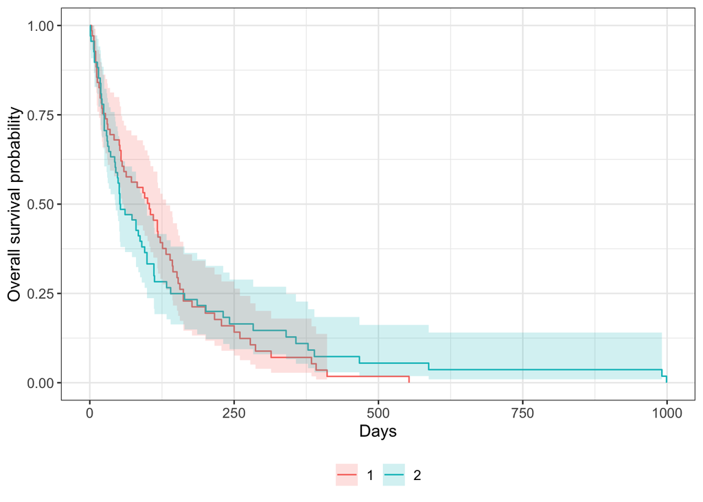

```r
response <- Surv(time = vet$time,
                 event = vet$status)
survfit2(response ~ 1 + trt,
         data = vet) %>%
  ggsurvfit() +
  labs(
    x = "Days",
    y = "Overall survival probability"
  ) +
  add_confidence_interval()
```

#### Part b

```r
survdiff(response ~ trt, data = vet)
```

```
Call:
survdiff(formula = response ~ trt, data = vet)

       N Observed Expected (O-E)^2/E (O-E)^2/V
trt=1 69       64     64.5   0.00388   0.00823
trt=2 68       64     63.5   0.00394   0.00823

 Chisq= 0  on 1 degrees of freedom, p= 0.9
```

> The p-value is quite large (0.9), so there is not sufficient evidence to claim there is a difference between the two survival curves across the two treatment groups.

#### Part c

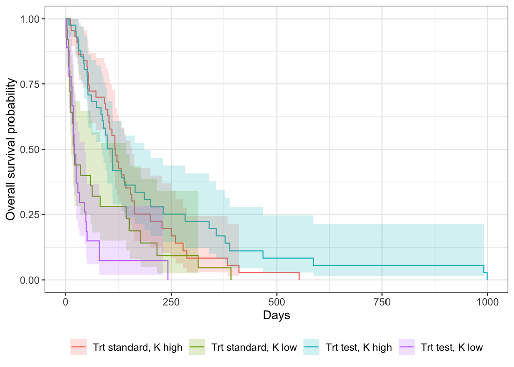

```r
vet <- vet %>%
  mutate(group = case_when((trt == 1 & karno < median(karno)) ~ "Trt standard, K low",
                           (trt == 1 & karno >= median(karno)) ~ "Trt standard, K high",
                           (trt == 2 & karno < median(karno)) ~ "Trt test, K low",
                           (trt == 2 & karno >= median(karno)) ~ "Trt test, K high")
         )

survfit2(response ~ 1 + group,
         data = vet) %>%
  ggsurvfit() +
  labs(
    x = "Days",
    y = "Overall survival probability"
  ) +
  add_confidence_interval()
```

```r
survdiff(response ~ group, data = vet)
```

```
Call:
survdiff(formula = response ~ group, data = vet)

                            N Observed Expected (O-E)^2/E (O-E)^2/V
group=Trt standard, K high 44       40     48.5      1.50      2.50
group=Trt standard, K low  25       24     16.0      4.02      4.68
group=Trt test, K high     41       38     53.2      4.33      8.01
group=Trt test, K low      27       26     10.3     23.85     27.39

 Chisq= 36  on 3 degrees of freedom, p= 7e-08
```

> After splitting the treatment groups into 4 by incorporating high/low Karnofsky scores (a measure of good/bad health), then there is a significant difference between the curves (p-value < 0.0001). We can reject the null hypothesis and claim the survival experiences were not identical for the 4 groups.

## E.13

#### Part a

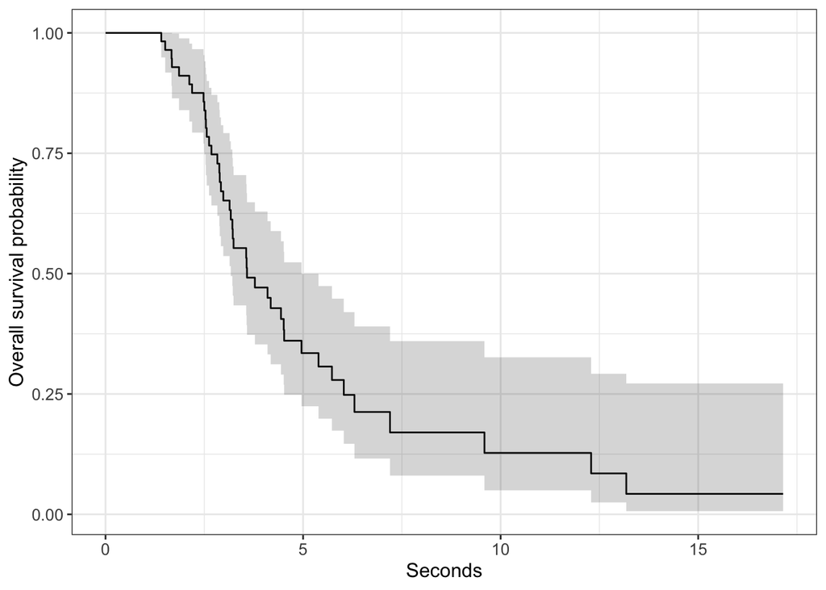

```r
horn <- read_csv("./data/C9 Hornhonk.csv") %>%
  clean_names() %>%
  mutate(complete = censor,
         censored = if_else(complete == 1, 0, 1))
response <- Surv(time = horn$seconds,
                 event = horn$complete)
m13 <- survfit2(response ~ 1,
         data = horn)
m13 %>%
  ggsurvfit() +
  labs(
    x = "Seconds",
    y = "Overall survival probability"
  ) +
  add_confidence_interval()
```

#### Part b

```r
print(m13, rmean = max(horn$seconds))
```

```
Call: survfit(formula = response ~ 1, data = horn)

      n events rmean* se(rmean) median 0.95LCL 0.95UCL
[1,] 57     42   5.29      0.63   3.58    3.17    4.96
    * restricted mean with upper limit =  17.1
```

```r
tidy(m13)
```

| time | n.risk | n.event | n.censor | estimate | std.error | conf.high | conf.low |
| --- | --- | --- | --- | --- | --- | --- | --- |
| 1.41 | 57 | 1 | 1 | 0.98245614 | 0.01769981 | 1.0000000 | 0.948958166 |
| 1.51 | 55 | 1 | 0 | 0.96459330 | 0.02549477 | 1.0000000 | 0.917578122 |
| 1.67 | 54 | 1 | 0 | 0.94673046 | 0.03161312 | 1.0000000 | 0.889850835 |
| 1.68 | 53 | 1 | 0 | 0.92886762 | 0.03690846 | 0.9985513 | 0.864046846 |
| 1.86 | 52 | 1 | 0 | 0.91100478 | 0.04170501 | 0.9885987 | 0.839501132 |
| 2.12 | 51 | 1 | 0 | 0.89314195 | 0.04616779 | 0.9777292 | 0.815872679 |
| 2.19 | 50 | 1 | 0 | 0.87527911 | 0.05039472 | 0.9661457 | 0.792958565 |
| 2.36 | 49 | 0 | 1 | 0.87527911 | 0.05039472 | 0.9661457 | 0.792958565 |
| 2.48 | 48 | 1 | 0 | 0.85704413 | 0.05461585 | 0.9538768 | 0.770041426 |
| 2.50 | 47 | 1 | 0 | 0.83880914 | 0.05869775 | 0.9410805 | 0.747652077 |

[output cut: 46 more lines]

```r
tidy(m13) %>%
  filter(estimate < .6) %>%
  slice(1)
```

| time | n.risk | n.event | n.censor | estimate | std.error | conf.high | conf.low |
| --- | --- | --- | --- | --- | --- | --- | --- |
| 3.21 | 31 | 1 | 0 | 0.5925306 | 0.1135675 | 0.7402521 | 0.4742878 |

> At 3.21 seconds, at least 40% of the motorists will have honked (60% have “survived”): $S(3.21)_{KM} \leq 1 - 40/100$

## E.15

#### Part a

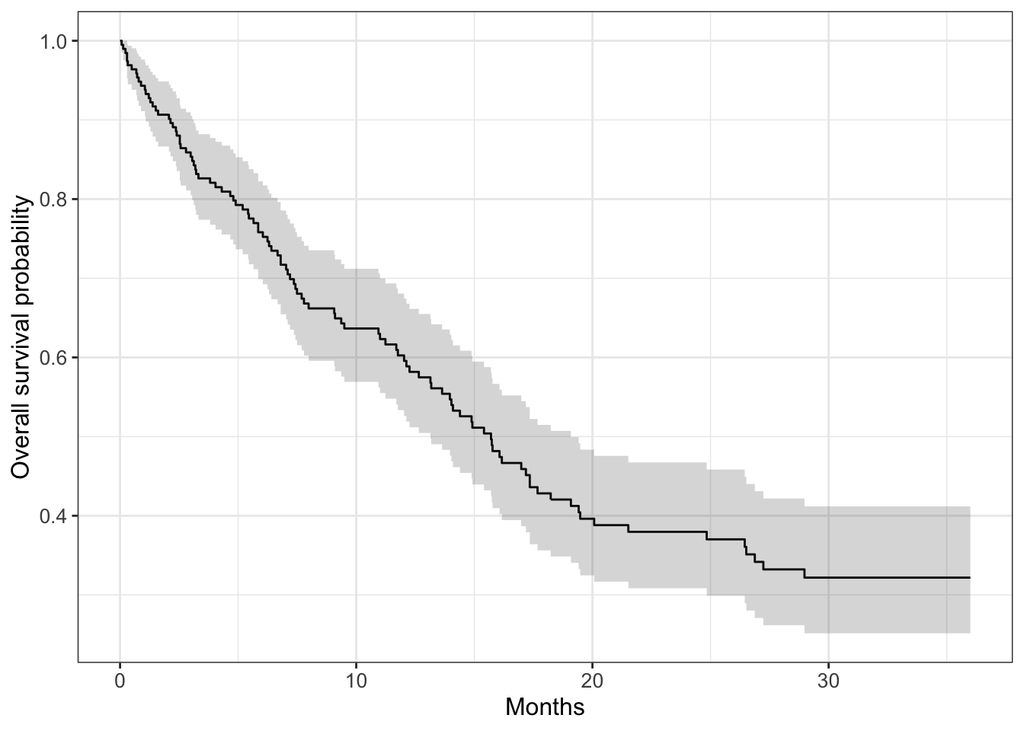

```r
rearrest <- read_csv("./data/C9 Rearrest.csv") %>%
  clean_names() %>%
  mutate(complete = censor,
         censored = if_else(complete == 1, 0, 1))
response <- Surv(time = rearrest$months,
                 event = rearrest$complete)
m15 <- survfit2(response ~ 1,
         data = rearrest)
m15 %>%
  ggsurvfit() +
  labs(
    x = "Months",
    y = "Overall survival probability"
  ) +
  add_confidence_interval()
```

#### Part b

```r
tidy(m15) %>%
  filter(estimate < .5) %>%
  slice(1)
```

| time | n.risk | n.event | n.censor | estimate | std.error | conf.high | conf.low |
| --- | --- | --- | --- | --- | --- | --- | --- |
| 15.70431 | 68 | 1 | 0 | 0.4965341 | 0.0798719 | 0.5806791 | 0.4245824 |

> At 15.7 months, at least half of the released inmates have been rearrested

#### Part c

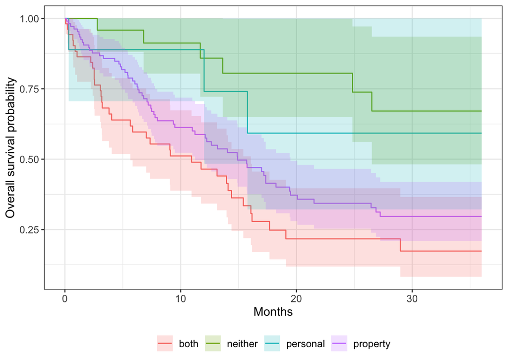

```r
rearrest <- rearrest %>%
  mutate(type = case_when(personal == 1 & property == 1 ~ "both",
                          personal == 1 & property == 0 ~ "personal",
                          personal == 0 & property == 1 ~ "property",
                          personal == 0 & property == 0 ~ "neither"))

m15c <- survfit2(response ~ type,
         data = rearrest)
m15c %>%
  ggsurvfit() +
  labs(
    x = "Months",
    y = "Overall survival probability"
  ) +
  add_confidence_interval()
```

```r
survdiff(response ~ type, data = rearrest)
```

```
Call:
survdiff(formula = response ~ type, data = rearrest)

                N Observed Expected (O-E)^2/E (O-E)^2/V
type=both      52       36    22.84     7.590     9.762
type=neither   27        6    19.33     9.191    11.387
type=personal   9        3     5.36     1.036     1.095
type=property 106       61    58.48     0.109     0.243

 Chisq= 18.2  on 3 degrees of freedom, p= 4e-04
```

> It appears that a much greater proportion of inmates who committed personal crimes remain free by the end of the study (~60%) compared to about 30% and 17% for those with property crimes and both personal and property crimes respectively. The p-value is quite small, indicating that the difference in survival curves between groups is significant.

## Reflection prompts

*Respond to each of the following after you have completed all exercises in this assignment*

*(RP1): What were the main concepts covered in this assignment?*

*(RP2): What’s one thing you understand better after completing these exercises?*

*(RP3): What exercise(s) gave you the most trouble? What was difficult about them/where did you get stuck?*